# Data Types - Strings, Dates, Times

Author

Ericka Quintero

Published

April 11, 2025

```r
library(tidyverse)
library(babynames)
library(nycflights13)
library(lubridate)
library(hms)
```

# Strings

## Your Turn 1

Fill in the blanks to:

1. Isolate the last letter of every name
2. Create a logical variable that displays whether the last letter is one of “a”, “e”, “i”, “o”, “u”, or “y”.
3. Use a weighted mean to calculate the proportion of children whose name ends in a vowel (by `year` and `sex`)
4. and then display the results as a line plot.

*(Hint: Be sure to remove each `_` before running the code)*

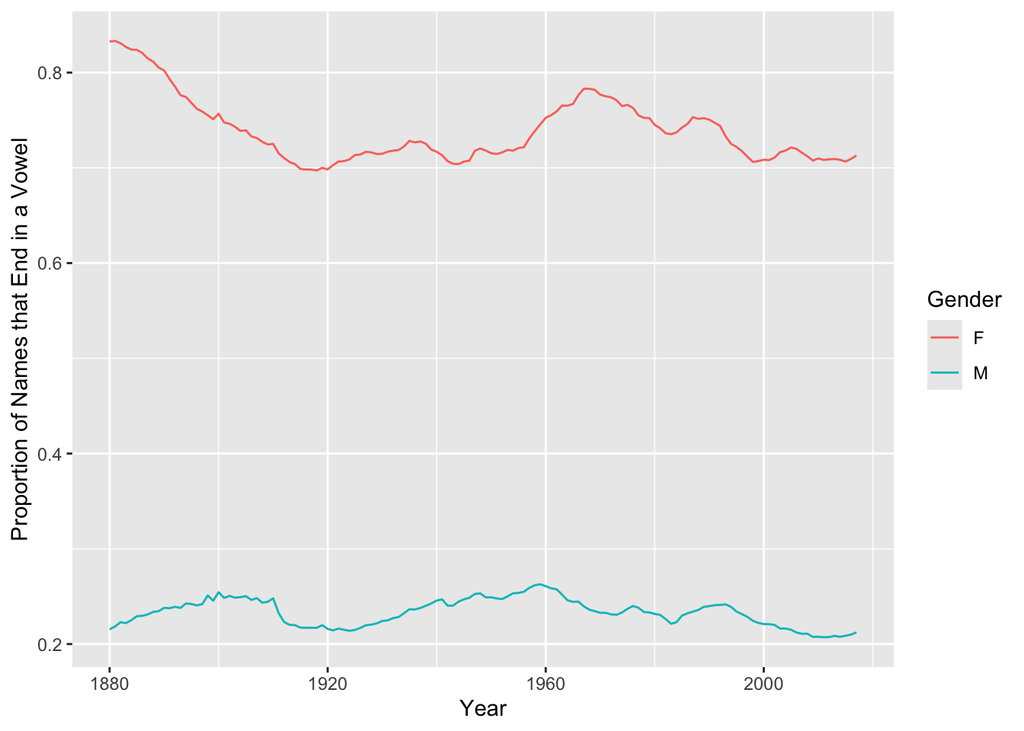

```r
babynames |>
  mutate(last = str_sub(name, -1),
          vowel = last %in% c("a", "e", "i", "o", "u", "y")) |>
  group_by(year, sex) |>
  summarise(p_vowel = weighted.mean(vowel, n)) |>
  ggplot() +
  geom_line(mapping = aes (x = year,
                           y = p_vowel,
                           color = sex)) +
  labs(x = "Year",
       y = "Proportion of Names that End in a Vowel",
       color = "Gender")
```

# Dates and Times

## Your Turn 2

What is the best time of day to fly?

Use the `hour` and `minute` variables in `flights` to make a new variable that shows the time of each flight as an hms.

Then use a smooth line to plot the relationship between time of day and `arr_delay`.

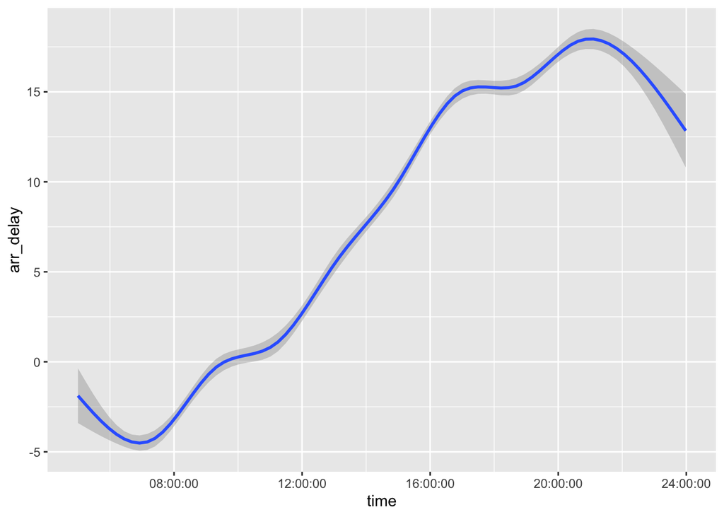

```r
flights |>
  mutate(time = hms(minutes = minute,
                    hours = hour)) |>
  ggplot(aes(x = time,
             y = arr_delay)) +
  #geom_point(alpha = 0.25) +
  geom_smooth()
```

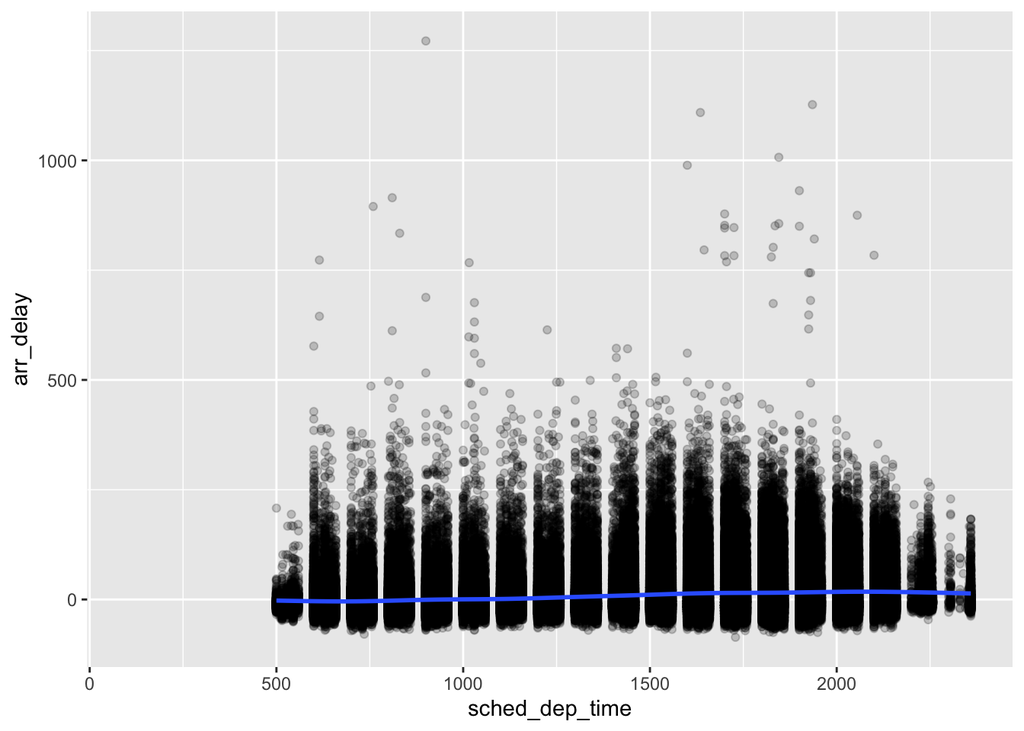

```r
flights |>
  ggplot(mapping = aes(x = sched_dep_time,
                       y = arr_delay)) +
  geom_point(alpha = 0.2) +
  geom_smooth()
```

## Your Turn 3

What is the best day of the week to fly?

Look at the code skeleton for Your Turn 4.

- What does each line do?
- What will the missing parts need to do?

> Mutate will create a new variable. Drop_na will remove missing values.

## Your Turn 4

Fill in the blank to:

Extract the day of the week of each flight (as a full name) from `time_hour`.

Plot the average arrival delay by day as a column chart (bar chart).

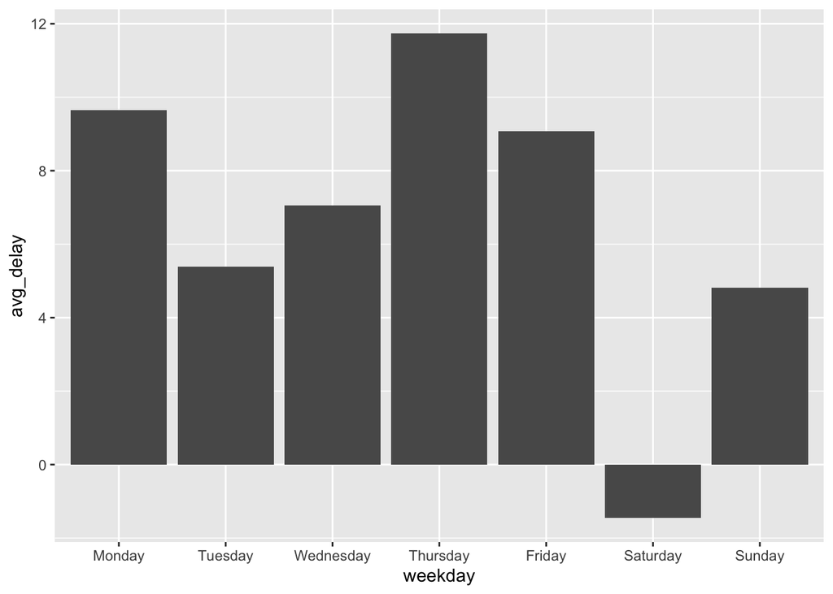

```r
flights |>
  mutate(weekday = wday(time_hour,
                        abbr = FALSE,
                        label = TRUE,
                        week_start = "Monday")) |>
  group_by(weekday) |>
  drop_na(arr_delay) |>
  summarise(avg_delay = mean(arr_delay)) |>
  ggplot() +
    geom_col(mapping = aes(x = weekday,
                           y = avg_delay))
```

# Take Aways

Dplyr gives you three *general* functions for manipulating data: `mutate()`, `summarise()`, and `group_by()`. Augment these with functions from the packages below, which focus on specific types of data.

| Package | Data Type |
| --- | --- |
| stringr | strings |
| forcats | factors |
| hms | times |
| lubridate | dates and times |